# Online learning apps from the learning cycle perspective: recent advances and best practices

Maria Osipenko[^1] and Mara Lein [^2]

## Introduction

Online learning applications with a large proportion of interactive, self-chosen content for individual learning paths become more and more essential in higher education. Especially, the lockdown during the COVID-19 pandemic enhanced a boom in the usage of such online learning applications and empirical studies of their effectiveness.

In their meta analysis of more than 50 publications with randomized or quasi-randomized experiments on online, blended, and face-to-face learning Means et al. (2010) report significant improvement in learning outcomes for online and blended formats. Some more recent meta studies report superiority of flipped classroom approach compared to traditional learning.

The purpose of the present paper is to review the recent advances and best practices for designing online learning units. Our primary goal is to identify effective parts and elements of online learning units essential for learning success and formulate recommendations for developing a such asynchronous online learning applications.

According to the taxonomy of Cooper (1988), our main focus rests on research outcomes. That is, we are interested primarily in identification of the features of computer aided online learning environments that provably improve learning performance and experience. Best practices of using those features are also of major interest in our analysis. Finally, since generalization of the findings to other teaching domains is favorable, we also overview the underlying behavioral theories where possible.

Our perspective is a neutral semi-automatic filtration and representation of available published literature according to our specific criteria provided below.

To pivot/structure our analysis, we adopt a 5E instructional framework, where designing of learning units follows the five-phase learning cycle: Engage, Explore, Explain, Elaborate, and Evaluate described in Bybee et al. (2006) and Hew et al. (2020). The first phase aims at engaging students e.g. by pointing out to real world problem or question, the second phase deals with the exploration of the problem, the next step attempts at explaining the phenomena based on existing knowledge, elaborating the content implies providing material for deeper understanding and exercising, and the last step evaluates learning success. Su, Chiu, and Wang (2010) use 5E learning cycle for designing an e-learning course and show that they enhance learning success.

Since modern e-learning systems incorporate adaptation or personalizing feature, we propose to extend the 5E model to 5E+E by adding the “6 Evolution”-step. This step does not concern the learning cycle itself but rather includes the analysis of learning system usability and improvement considerations towards developing an adaptive personalized e-learning system, which adapts to individual learning preferences. In the following, we undertake a more detailed overview of the learning cycle phases.

**Engagement.** Various definitions of student engagement exist. For instance, Hu, Kuh, and Li (2008) understand engagement as “the amount of effort dedicated to educational activities that bring out ideal performance”. A. Lewis et al. (2010) see engagement as “the extent to which learners’ thoughts, feelings, and activities are actively involved in learning”.

Wong and Liem (2022) define learning engagement as “students’ psychological state of activity that affords them to feel activated, exert effort, and be absorbed during learning activities”. Based on known theories about the concept, they differentiate between behavioral, cognitive and emotional components in engagement assessment. The authors view learning engagement as a multilevel construct varying with learning context and time. In this sense, engagement is superordinate to the other stages as it nurtures carrying out the learning activities.

Lee, Song, and Hong (2019) identify the following aspects as indicators of engagement: 1) behavioral - learning effort (self completed units, invested time), participation in class activities (attendance, asking questions), interaction (between learner and instructor), 2) cognitive task - solving (knowledge formation, application, reflection/believes about achievement, focus), learning management (self-direction, schedule), 3) emotional - learning satisfaction (interest, expectations, enjoyment), sense of belonging (degree of connection in the learning community), learning passion (willingness to confront challenges in the learning process).

Skilling, Bobis, and Martin (2020) measures seven adaptive factors as self-efficacy, mastery orientation, valuing, persistence, planning, task management, and enjoyment and the five maladaptive factor variables as anxiety, failure avoidance, uncertain control, self-handicapping and disengagement to connect engagement, motivation and achievement in particular towards secondary school mathematics.

Maroco et al. (2016) develop a questionnaire in order to address university students engagement. Assunção et al. (2020) test the questionnaire and confirm that it can produce reliable and valid data on academic engagement of university students. Tomás et al. (2022) assess reliability and validity of further two self-assessment tools for quantifying engagement.

**Exploration.** The exploration phase is exemplified in Bybee et al. (2006) through experimental activities, preliminary investigation or using prior knowledge to generate new outcomes. Student activities encompass e.g. stating and testing predictions and hypotheses, trying alternatives and generating new ideas. Depending on the subject, such activities can be implemented online through interactive applications with manipulatives (e.g. varying input parameters producing another output), simulations, and scenario-based exploration. These “hands-on” experience has been shown to enhance learning success in the literature, see Meylani, Bitter, and Legacy (2015). It is also connected to experiential learning (see Morris (2020)), where concrete experience is at core of the learning process.

**Elaboration** As Bybee et al. (2006), elaboration enhances deeper and broader understanding and application of new skills. We interpret this stage also as the possibility for students to intensively exercise and gain routinized skills in solving problems associated with new concepts. Also, in asynchronous online learning, where direct instructor feedback is not available, a self-testing possibility with direct feedback should be provided as Meylani, Bitter, and Legacy (2015). To engage students more in exercising new concepts and attaining routinized skills, gamified learning actovities can be used. As noted in Demmese, Yuan, and Dicheva (n.d.), such gamified activities can aid routine practice motivating to solve more exercises.

**Evaluation** In this phase, ability assessment and the evaluation of student progress takes place. In online format, individual ability assessment is realized through quizzes with an end score. Meylani, Bitter, and Legacy (2015) points out the importance of self-monitoring in an online framework. An overview of completed activities and attained test scores can be implemented in form of learning analytics dashboard, which have been shown to enable learners to making informed decisions (Susnjak, Ramaswami, and Mathrani (2022)).

**Evolution.** Evolve stage includes improving e-learning environment based on direct feedback, questionnaire (as e.g. system usability scale, J. R. Lewis (2018)) and learning analytics and adding personalized features. Meylani, Bitter, and Legacy (2015) stresses the importance of providing a form of learner control over the available online resources. Based on previous learning paths, an individual recommendation for each learner might nehance learning success. As noted in Katsaris and Vidakis (2021) personalized e-learning environments adapting to individual learning preferences are at rise. They have the potential to support individual learning process optimally. For instance, Fatahi (2019) propose adaptation of e-learning environments based on emotion and personality. Khamparia and Pandey (2020) review the methodologies, how e-learning adaptation is realized based on automatic assessment of learning styles and point out an overall utility for learners success.

Our coverage strategy is representative sample of papers available through the OpenAlex API which indexes 209M works collected from various sources as Crossref, PubMed and institutional and preprint repositories as arXiv providing all together 124,000 publishing venues as Priem, Piwowar, and Orr (2022).

We pivot our analysis based on citation intensity, concentrating on most cited papers normalized on their age since publication. The results are organized conceptually and are meant for general researchers and practitioners.

We follow four steps of Herz et al. (2010):

- define the review scope
- conceptualization of the topic (definitions of the topic: learning dashboards) -> based on the previous review Matcha et al. (2020)
- literature search: journal search, database search, keyword search, backward (citations in the articles)/forward search (citations of the articles of keyword search)
- literature analysis and synthesis (define main dimensions)

We obtain topic keywords following the definitions of the 5E stages from three papers: Eisenkraft (2003), Duran and Duran (2004), and Bybee et al. (2006). For the last stage of evolution, we adopt the descriptions of adaptive e-learning environments from Özyurt and Özyurt (2015), El-Sabagh (2021), and Kolekar, Pai, and M M (2019).

## Methods

### Searching and filtering the recent works on online learning

Subsequently, we filter the publisher to be under the top 20 ranking of GoogleScholar in education, educational technology, and educational psychology (https://scholar.google.com/citations?view_op=top_venues&hl=en&vq=eng_educationaltechnology (as of 2023-04-17)). The filtering yields 5474 articles.

Finally, we remove articles without abstracts available in the database, and are left with 5089 articles for further analysis.

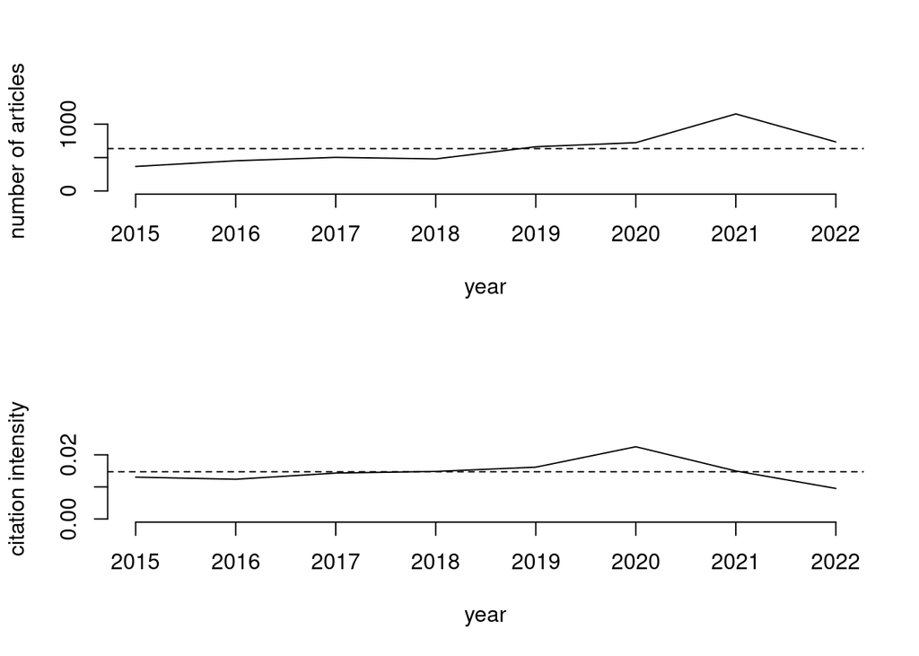

Figure 1: Upper panel: the number of articles in the selection on the time line of their publication date (2023 is omitted, dashed line marks the mean value). Bottom panel: the average citation intensity, computed as the number of citations divided by the years since publication.

In Figure 1 (upper panel) we plot the number of articles in the selection on the time line of their publication date (2023 is omitted, dashed line marks the mean value). The figure reveals a upward general trend in publication number and a peak in 2021. In the bottom panel of Figure 1 the average citation intensity, computed as the number of citations divided by the years since publication, is reported. The citation intensity of papers published in 2020 is the highest. Apart from 2020, the overall citation intensity seems to stay fairly on the same level.

To efficiently incorporate all resulting articles in our analysis, we employ an automatic topic identification via Latent Dirichlet Allocation (LDA), which was also used in Gurcan (2021) for identification of emerging trends in e-learning. To target topics which are of primary interest for researchers, Eshima, Imai, and Sasaki (2023) propose to equip the model with predefined keywords.

For our analysis, we tie the keywords on the definitions and descriptions of the 6E stages, such that the obtained topics are pivoted by the learning cycle phases above. For that reason, a keyword assisted LDA model is fitted to the data for keywords based topic extraction using the R-Package keyATM (Eshima, Imai, and Sasaki (2023)).

### Fiting keyATM

Table 1 documents the provided keywords for the six keyword topics. These keywords are used as input into keyword assisted LDA model to facilitate targeted extraction of 5E+E structured topics.

Table 1: The chosen keywords for the six keyword topics to assist topic extraction.

| engagement | exploration | explanation | elaboration | evaluation | evolution |
| --- | --- | --- | --- | --- | --- |
| engag | explor | explain | problem | assess | adapt |
| motiv | experi | instruct | solv | evalu | individu |
| emot | interact | knowledg | practic | test | improv |
| promot | activ | theori | applic | feedback | behavior |

Figure 2 presents the chosen keywords with the respective proportional occurrence on the titles and abstracts of the considered collection of papers.

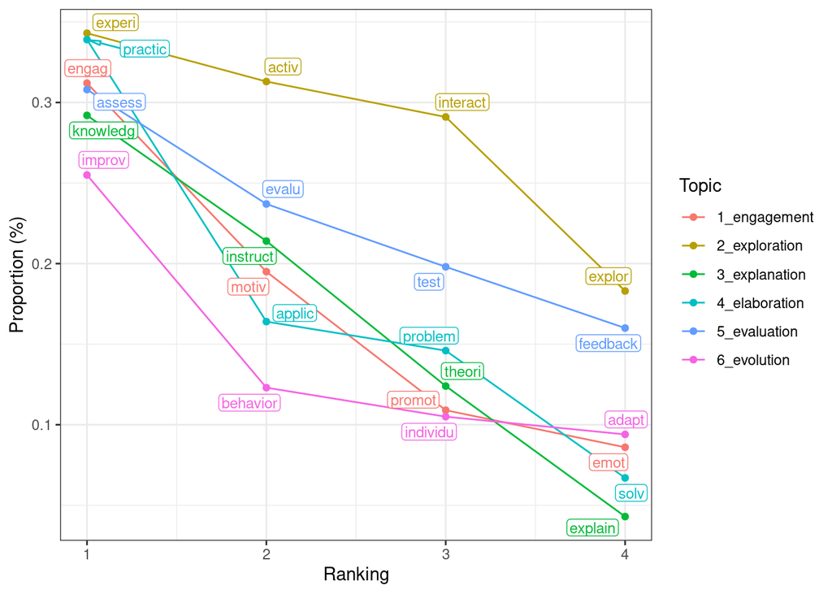

Figure 2: The chosen keywords and their proportions in the titles and abstracts of the considerred collection of papers.

In the following, we fit a keyword assisted topic model using the keywords above for the six keyword topics and further three keywordless topics.

Based on screening the titles of the top 20 papers with the highest topic proportion, we label the keywordless topics as 7. research directions, 8. technology acceptance, and 9. challenges in distance education (henceforth research_dir, tech_accept, and distanc_educ respectively).

Table 2: The 20 topwords for each topic. The keywords matched on the respective topic are marked by a check mark. The keywords in the topwords of a foreign topic are label by the number of the keyword topic.

| 1_engagement | 2_exploration | 3_explanation | 4_elaboration | 5_evaluation | 6_evolution | 7_research_dir | 8_tech_accept | 9_distanc_educ |
| --- | --- | --- | --- | --- | --- | --- | --- | --- |
| self | interact [✓] | teacher | teach | assess [✓] | model | research | languag | covid |
| engag [✓] | cours | school | develop | group | cours | digit | mobil | pandem |
| motiv [✓] | social | mathemat | base | effect | system | higher | english | face |
| academ | design | instruct [✓] | design | test [✓] | mooc | review | accept | distanc |
| factor | activ [✓] | teach | practic [✓] | feedback [✓] | data | develop | intent | teach |
| effect | discuss | stem | process | evalu [✓] | learner | univers | model | univers |
| level | environ | servic | effect | perform | improv [✓] | articl | factor | institut |
| posit | experi [✓] | knowledg [✓] | applic [✓] | peer | base | analysi | perceiv | higher |
| signific | learner | develop | comput | read | open | paper | attitud | remot |
| relat | collabor | profession | method | result | qualiti | literatur | adopt | lectur |
| satisfact | particip | pre | skill | experiment | behavior [✓] | inform | influenc | challeng |
| relationship | support | children | problem [✓] | control | platform | context | toward | faculti |
| regul | blend | parent | paper | two | analysi | identifi | research | emerg |
| influenc | approach | ict | implement | base | individu [✓] | increas | foreign | experi [2] |
| efficaci | research | program | new | score | result | need | efl | time |
| perform | instructor | support | result | differ | propos | relat | comput | transit |
| result | engag [1] | integr | knowledg [3] | write | perform | futur | devic | survey |
| emot [✓] | class | classroom | integr | compar | user | profession | univers | chang |
| perceiv | explor [✓] | tpack | tool | intervent | manag | focus | usag | academ |
| differ | presenc | secondari | virtual | signific | adapt [✓] | includ | theori [3] | due |

Table 2 documents the resulting 20 topwords for each topic with the keywords marked by a check mark. As seen, the most keywords are under the top 20, giving appropriate assistance to the topic extraction. The keyword, which are also under the top twenty in a foreign topic are labeled by the keyword topic number. For example, “engag” was given as a keyword for topic 1 engagement. However, it is also under the top 20 for topic 2 exploration. Such interrelatedness of the keywords is relatively rare under the top 20, which also supports appropriate assistance of the keywords for the topic finding.

Figure 3 shows the expected topic proportions per paper The largest topic proportions for keyword assisted topics fall on the topics of elaboration and exploration followed by evolution. The smallest expected proportion among the keyword assisted topics is assigned to the explanation topic. From the keywordless topics, the first one with the top words “research”, “digit”, “higher”, “review” is dominating.

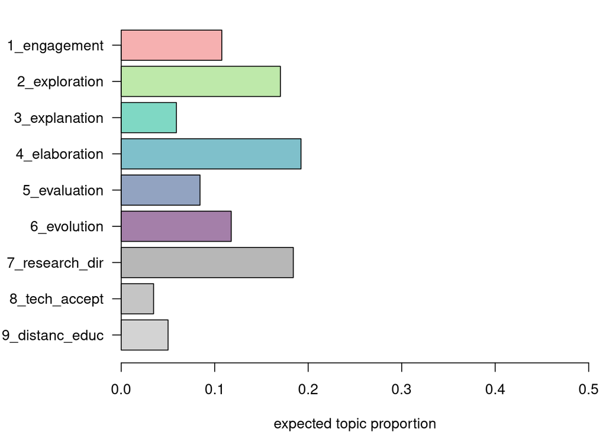

Figure 3: Expected topic proportions of the extracted topics and the top topic words.

In general, the expected topic proportions are rather moderate, meaning that the most papers contain more more than one topic with rather high probability.

To inspect the topwords together with their relative weights in topics, we provide word clouds with top 20 topic shaping words for each topic in Figure 4.

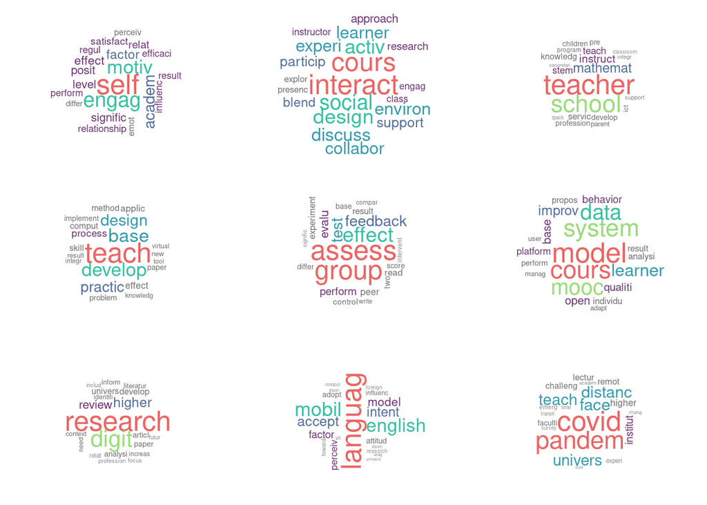

Figure 4: Wordclouds based on the word weights in the six keyword assisted topics: engagement, exploration, explanation, elaboration, evaluation, evolution, as well as three keywordless topics (from left to the right, from top to bottom).

The wordclouds in Figure 4 are based on the word weights in the six keyword assisted topics: engagement, exploration, explanation, elaboration, evaluation, evolution, as well as three keywordless topics (from left to the right, from top to bottom).

Figure 5 shows the dynamics of topic proportions summarized for the available publication years.

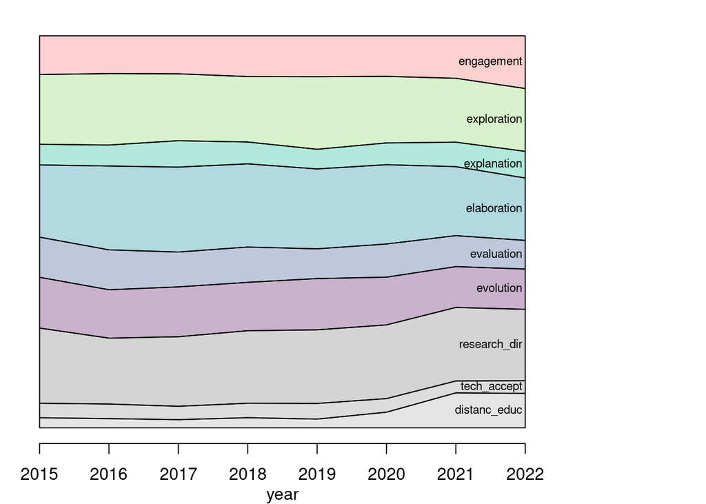

Figure 5: Proportion of of topics in the considered articles over publication years

In Figure 5, we observe a slight increase in the literature on engagement since 2021 and substantial increase in works on challenges in distance education mainly due to pandemic restrictions in the period 2020-2021.

### Exploring the interrelations between topics

To further explore the interrelations between the documents with different topics, we compute and plot the topic network with topics as vertices and two different link types as edges. The first link type deals with the expected topic proportion in documents with high proportion of a vertices-topic. The higher this expected proportion is, the thicker is the link line. For the computation top 100 documents belonging to each topic are extracted. The first network is shown in the left panel of Figure 6. The second network type is based on the reciprocal/mutual citations of top 100 documents belonging to each topic. For the visualization of the network, we adjust the thickness of the edges depending on the citation intensity. The resulting network is shown on the right panel of Figure 6.

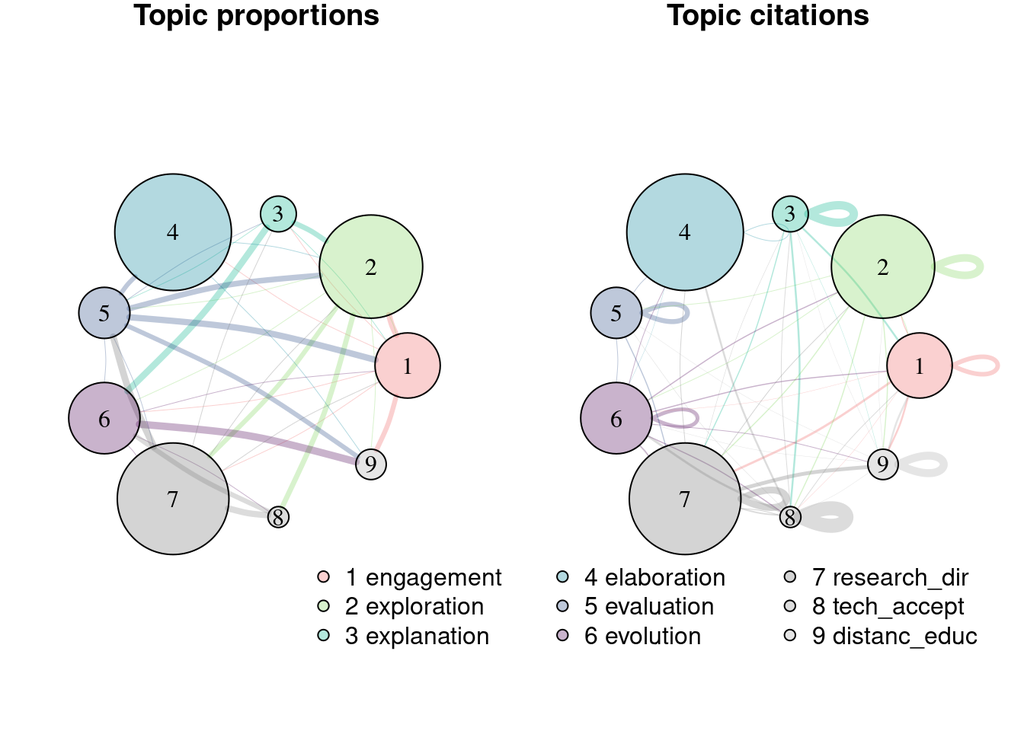

Figure 6: Left panel: a network graph for topic proportions depicting the expected proportion of edge-connected topics in a document with a high proportion of vertice-topic. Right panel: a network graph for topic citations showing the expected citations of documents with a high proportion of edge-connected topics in a document with a high proportion of vertice-topic. Both graphical representations are obtained using 100 documents with the highest topic proportion for each topic.

In the left panel of Figure 6, we see, that articles with high proportion of engagement topic tend to contain a high proportion of exploration issues and vice versa, as well as to relate to challenges on distance education. Articles with high proportion of explanation topic are likely to contain also exploration and evolution themes. The evaluation topic seems to be at most interrelated especially to the topics in engagement, exploration, elaboration, and challenges in distance education. Technological acceptance in is tightened to 6 evolution of learning systems and 7 research directions.

## Explore your own keywords and their relation to topics

As an example, we use an overarching topic “gamification” and keywords “game”, “play”, “excit”.

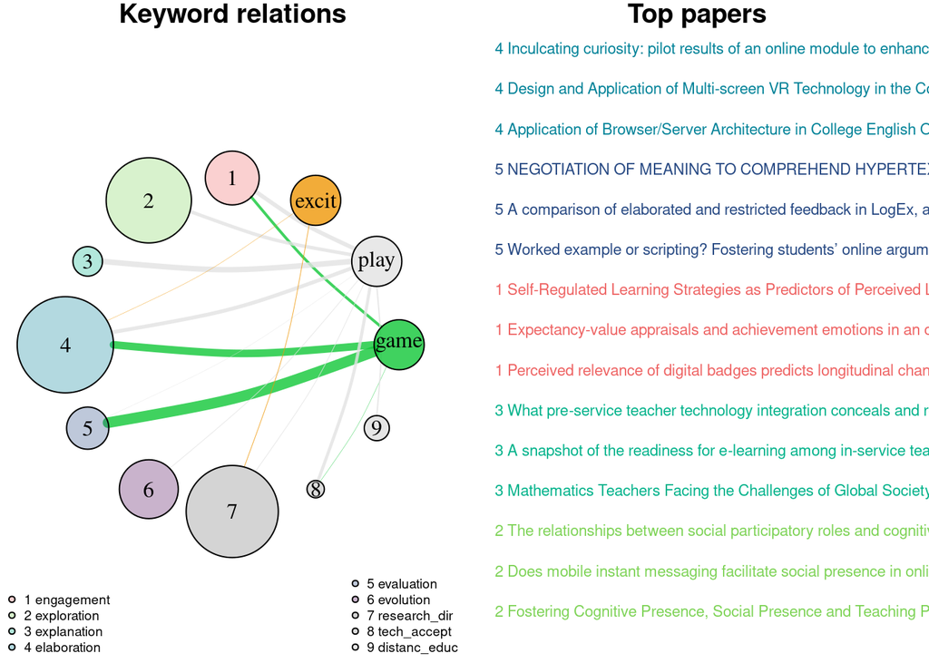

[interactive chart not shown]

## Literature

Assunção, Hugo, Su-Wei Lin, Pou Seong Sit, Kwok-cheung Cheung, Heidi Harju-Luukkainen, Thomas Smith, Benvindo Maloa, et al. 2020. “University Student Engagement Inventory (USEI): Transcultural Validity Evidence Across Four Continents.” *Frontiers in Psychology* 10 (January): 1–12. https://doi.org/10.3389/fpsyg.2019.02796.

Bybee, Rodger, Joseph Taylor, April Gardner, Pamela Scotter, Janet Carlson, Anne Westbrook, and Nancy Landes. 2006. “The BSCS 5e Instructional Model: Origins, Effectiveness, and Applications.” *BSCS*, January.

Cooper, Harris. 1988. “Organizing Knowledge Syntheses: A Taxonomy of Literature Reviews.” *Knowledge in Society* 1: 104–26.

Demmese, F., X. Yuan, and D. Dicheva. n.d. “Evaluating the Effectiveness of Gamification on Students’ Performance in a Cybersecurity Course.” *Journal of the Colloquium for Information System Security Education* 8 (1). https://par.nsf.gov/biblio/10290874.

Duran, Lena Ballone, and Emilio Duran. 2004. “The 5e Instructional Model: A Learning Cycle Approach for Inquiry-Based Science Teaching.” *Science Education Review* 3 (2): 49–58.

Eisenkraft, Arthur. 2003. “Expanding the 5e Model.” *Science Teacher* 70 (6): 56–59.

El-Sabagh, Hassan. 2021. “Adaptive e-Learning Environment Based on Learning Styles and Its Impact on Development Students’ Engagement” 18 (October): 1–24. https://doi.org/10.1186/s41239-021-00289-4.

Eshima, Shusei, Kosuke Imai, and Tomoya Sasaki. 2023. “Keyword-Assisted Topic Models.” *American Journal of Political Science* n/a (n/a). https://doi.org/https://doi.org/10.1111/ajps.12779.

Fatahi, Somayeh. 2019. “An Experimental Study on an Adaptive e-Learning Environment Based on Learner’s Personality and Emotion.” *Education and Information Technologies* 24 (July). https://doi.org/10.1007/s10639-019-09868-5.

Gurcan, Ozcan ; Cagitay, Fatih ; Ozyurt. 2021. “Investigation of Emerging Trends in the e-Learning Field Using Latent Dirichlet Allocation.” *International Review of Research in Open and Distributed Learning* 22 (2): 1–18. https://doi.org/https://doi.org/10.19173/irrodl.v22i2.5358.

Herz, Thomas, Florian Hamel, Falk Uebernickel, and Walter Brenner. 2010. “Deriving a Research Agenda for the Management of Multisourcing Relationships Based on a Literature Review.” *Http://Www.alexandria.unisg.ch/Publikationen/69319* 3 (January).

Hew, Khe, Chengyuan Jia, Donn Gonda, and Shurui Bai. 2020. “Transitioning to the "New Normal" of Learning in Unpredictable Times: Pedagogical Practices and Learning Performance in Fully Online Flipped Classrooms.” *International Journal of Educational Technology in Higher Education* 17 (December). https://doi.org/10.1186/s41239-020-00234-x.

Hu, Shouping, George Kuh, and Shaoqing Li. 2008. “The Effects of Engagement in Inquiry-Oriented Activities on Student Learning and Personal Development.” *Innovative Higher Education* 33 (August): 71–81. https://doi.org/10.1007/s10755-008-9066-z.

Katsaris, Iraklis, and Nikolas Vidakis. 2021. “Adaptive e-Learning Systems Through Learning Styles: A Review of the Literature.” *Advances in Mobile Learning Educational Research* 1 (2): 124–45. https://doi.org/10.25082/AMLER.2021.02.007.

Khamparia, Aditya, and Babita Pandey. 2020. “Association of Learning Styles with Different e-Learning Problems: A Systematic Review and Classification.” *Education and Information Technologies* 25 (March): 1–29. https://doi.org/10.1007/s10639-019-10028-y.

Kolekar, Sucheta, Radhika Pai, and Manohara M M. 2019. “Rule Based Adaptive User Interface for Adaptive e-Learning System.” *Education and Information Technologies* 24 (January). https://doi.org/10.1007/s10639-018-9788-1.

Lee, Jeongju, Hae-Deok Song, and Ah Jeong Hong. 2019. “Exploring Factors, and Indicators for Measuring Students’ Sustainable Engagement in e-Learning.” *Sustainability* 11 (4). https://doi.org/10.3390/su11040985.

Lewis, Ashley, E Huebner, Patrick Malone, and Robert Valois. 2010. “Life Satisfaction and Student Engagement in Adolescents.” *Journal of Youth and Adolescence* 40 (March): 249–62. https://doi.org/10.1007/s10964-010-9517-6.

Lewis, James R. 2018. “The System Usability Scale: Past, Present, and Future.” *International Journal of Human–Computer Interaction* 34 (7): 577–90. https://doi.org/10.1080/10447318.2018.1455307.

Maroco, João, Ana Maroco, Juliana Campos, and Jennifer Fredricks. 2016. “University Student’s Engagement: Development of the University Student Engagement Inventory (USEI).” *Psicologia: Reflexão e Crítica* 29 (December). https://doi.org/10.1186/s41155-016-0042-8.

Martin, Florence, Ting Sun, and Carl D. Westine. 2020. “A Systematic Review of Research on Online Teaching and Learning from 2009 to 2018.” *Computers & Education* 159: 104009. https://doi.org/https://doi.org/10.1016/j.compedu.2020.104009.

Matcha, Wannisa, Nora’ayu Ahmad Uzir, Dragan Gašević, and Abelardo Pardo. 2020. “A Systematic Review of Empirical Studies on Learning Analytics Dashboards: A Self-Regulated Learning Perspective.” *IEEE Transactions on Learning Technologies* 13 (2): 226–45. https://doi.org/10.1109/TLT.2019.2916802.

Means, Barbara, Yukie Toyama, Robert Murphy, Marianne Bakia, Karla Jones, and Evaluation Planning. 2010. “Evaluation of Evidence-Based Practices in Online Learning: A Meta-Analysis and Review of Online Learning Studies.” *Http://Lst-Iiep.iiep-Unesco.org/Cgi-Bin/Wwwi32.exe/[in=epidoc1.in]/?t2000=027003/(100)* 115 (January).

Meylani, Rusen, Gary Bitter, and Jane Legacy. 2015. “Desirable Characteristics of an Ideal Online Learning Environment.” *Journal of Educational and Social Research*, January. https://doi.org/10.5901/jesr.2015.v5n1p203.

Morris, Thomas Howard. 2020. “Experiential Learning – a Systematic Review and Revision of Kolb’s Model.” *Interactive Learning Environments* 28 (8): 1064–77. https://doi.org/10.1080/10494820.2019.1570279.

Özyurt, Özcan, and Hacer Özyurt. 2015. “Learning Style Based Individualized Adaptive e-Learning Environments: Content Analysis of the Articles Published from 2005 to 2014.” *Computers in Human Behavior* 52: 349–58. https://doi.org/https://doi.org/10.1016/j.chb.2015.06.020.

Priem, Jason, Heather Piwowar, and Richard Orr. 2022. “OpenAlex: A Fully-Open Index of Scholarly Works, Authors, Venues, Institutions, and Concepts.” https://arxiv.org/abs/2205.01833.

Shi, Yinghui, Yanqiong Ma, Jason MacLeod, and Harrison Hao Yang. 2019. “College Students’ Cognitive Learning Outcomes in Flipped Classroom Instruction: A Meta-Analysis of the Empirical Literature.” *Journal of Computers in Education* 7 (May). https://doi.org/10.1007/s40692-019-00142-8.

Skilling, Karen, Janette Bobis, and Andrew Martin. 2020. “The ‘Ins and Outs’ of Student Engagement in Mathematics: Shifts in Engagement Factors Among High and Low Achievers.” *Mathematics Education Research Journal* 33 (February): 1–25. https://doi.org/10.1007/s13394-020-00313-2.

Su, C. Y., C. H. Chiu, and T. I. Wang. 2010. “The Development of SCORM-Conformant Learning Content Based on the Learning Cycle Using Participatory Design.” *Journal of Computer Assisted Learning* 26 (5): 392–406. https://doi.org/https://doi.org/10.1111/j.1365-2729.2010.00355.x.

Susnjak, Teo, Gomathy Ramaswami, and Anuradha Mathrani. 2022. “Learning Analytics Dashboard: A Tool for Providing Actionable Insights to Learners.” *International Journal of Educational Technology in Higher Education* 19 (February): 12. https://doi.org/10.1186/s41239-021-00313-7.

Tomás, José, Melchor Gutiérrez, Salvador Alberola, and Sylvia Georgieva. 2022. “Psychometric Properties of Two Major Approaches to Measure School Engagement in University Students.” *Current Psychology* 41 (May). https://doi.org/10.1007/s12144-020-00769-2.

Wong, Zi, and Gregory Arief Liem. 2022. “Student Engagement: Current State of the Construct, Conceptual Refinement, and Future Research Directions.” *Educational Psychology Review* 34 (March): 1–32. https://doi.org/10.1007/s10648-021-09628-3.

Ying, Xiu, and Penny Thompson. 2020. “Flipped University Class: A Study of Motivation and Learning.” *Journal of Information Technology Education: Research* 19 (January): 041–63. https://doi.org/10.28945/4500.

[^1]: Hochschule für Wirtschaft und Recht Berlin; osipenko@hwr-berlin.de
[^2]: Hochschule für Wirtschaft und Recht Berlin